# Concession Promotion Impact & Cannibalization

- Show All Code
- Hide All Code
- View Source

Do the Miller High Life and 6-1 hot dog promotions grow sales, or just shift them?

Published

August 27, 2026

# 1 Why we ran this analysis

Discounting the Miller High Life 12 oz beer and the 6-1 all-beef hot dog reliably sells more of those items. The business question is different: **where does that volume come from?** Two possibilities have very different implications:

- **Incremental:** the discount brings in spending that would not otherwise happen. The promotion grows the category and is a net gain (subject to margin).
- **Cannibalization:** fans simply switch from a full-price item to the discounted one. The promotion shifts revenue around the menu without growing it.

This report separates those two stories for beer and for hot dogs, and adds a Market-stand view of whether the promotions draw extra traffic.

Promotions covered. Beer promotions = all three; hot dog promotions = Slide into Summer and Spring Value Games.

| Promotion | Window | Discounts | Game tiers |
| --- | --- | --- | --- |
| Slide into Summer (2025) | 5/30 to 6/05 | $2 6-1 hot dogs, $4 Miller High Life 12oz | 0, 1, 3, 4 |
| Spring Value Games (2026) | 3/30-4/01, 4/13-4/15, 4/28 | $2.50 6-1 hot dogs, $4 Miller High Life 12oz | 5 |
| May in the A (2026) | 5/12-5/14, 5/17, 5/22, 5/24 | $3 Miller High Life 12oz, $2 ice cream sandwiches | 2, 3 |

# 2 What we measured, and how

We compared item sales on promotion games against comparable non-promotion games, using four complementary methods so the conclusion does not rest on any single lens.

The four methods.

| Method | Plain-English question | How confounding is handled |
| --- | --- | --- |
| A. Category and family growth | Did total beer / total hot dogs (and close substitutes) go up or down per fan? | Matched on game tier, then re-checked against non-promo games from the same part of the season |
| B. Within-game comparison | Within the same game, did the featured item pull ahead of its close substitutes? | Compares items inside the same game, so crowd size, weather, and opponent cancel out |
| C. Item-by-item | Which specific items moved, and is it statistically real? | Same two lenses; corrected for testing many items at once |
| D. Market-stand traffic | Did the Market stands that hosted the promo draw more traffic? | Compares the change at Market stands to the change at similar comparison stands |

A few choices worth knowing:

- **Everything is measured per fan** (per turnstile entry), so a busier or quieter night does not by itself look like a promotion effect.
- **We look at every across-game result two ways.** A *simple comparison* matches only on game tier (a stand-in for expected attendance). A *season-matched* comparison goes further: because all of the promotion games fall in the first half of the season (April through early June, none in mid or late summer), it compares each promotion to non-promotion games **from the same weeks of the calendar**, with a light adjustment for month and weekend. This matters because beer, especially the larger pours, sells very differently in cool spring than in the summer heat for reasons that have nothing to do with the promotion. When the two lenses disagree, the simple number was mostly a reflection of *when* the promotion ran, and we rely on the season-matched result.
- **Close substitutes, not the whole menu.** For beer we compare against other domestic and light beers (Coors Light, Miller Lite, Coors Banquet), including the larger pours a fan might trade down from. For hot dogs we compare against the other hot dog sizes and adjacent staples (burgers, chicken tenders, nachos, jumbo pretzel). A “rate ratio” of 1.15 means 15% more units per fan; 1.0 means no change.

Items grouped into families. ‘contrast’ items are shown for reference only and are not counted as substitutes.

| Category | Family | Items |
| --- | --- | --- |
| Beer | beer_domestic_sub | Coors Light 16oz, Miller Lite 16oz |
| Beer | beer_largepour_sub | Coors Light 24oz, Miller Lite 24oz |
| Beer | beer_promoted | Miller High Life 12oz |
| Beer | contrast | Blue Moon 16oz, Leinenkugel Summer Shandy 16oz, Sweetwater Atlanta OG 16oz |
| Food | food_adjacent_entree_sub | Burger Basket, Chicken Tender Basket, Pizza Pepperoni Slice 18 |
| Food | food_adjacent_snack_sub | Pretzel Jumbo, Snack Nachos Classic |
| Food | food_hotdog_sub | Hot Dog All Beef 2-1, Hot Dog All Beef 4-1 |
| Food | food_promoted | Hot Dog All Beef 6-1 |

## 2.1 Data and its limits

Data used.

| Source | Level of detail |
| --- | --- |
| Item-level sales, 2025-26 | Every item, every game (ballpark-wide, no stand breakdown) |
| Stand-level sales, 2025-26 | Every stand, every game (transactions and revenue, no item detail) |
| Concession KPIs | Attendance (turnstile) and promotion flags per game |
| Schedule | Game tier, day, weekend, opponent, time of year |

Two data limits shape what is answerable. Item sales are **not broken out by stand**, so item-level cannibalization can only be measured ballpark-wide, not for the Market specifically. Stand sales carry **no item detail**, so the Market-specific view (Method D) is limited to transactions and revenue. There is no weather data; the within-game and Market-stand methods remove weather automatically, which is one reason we weight them heavily.

We also built a complete item-by-game table so that a game where a comparison item did not sell counts as a genuine zero rather than a missing value, which keeps the comparisons honest.

Completeness of the item-by-game table.

| Category | Item-game rows | Filled-in zeros | % filled |
| --- | --- | --- | --- |
| Beer | 1296 | 0 | 0 |
| Food | 1296 | 0 | 0 |

# 3 What we found

## 3.1 Did the category grow, or did comparable items shrink?

The clearest test of cannibalization: if the promotion only shifts sales, the featured item rises but the **category total per fan stays flat** and close substitutes fall. If the promotion grows the business, the category total rises.

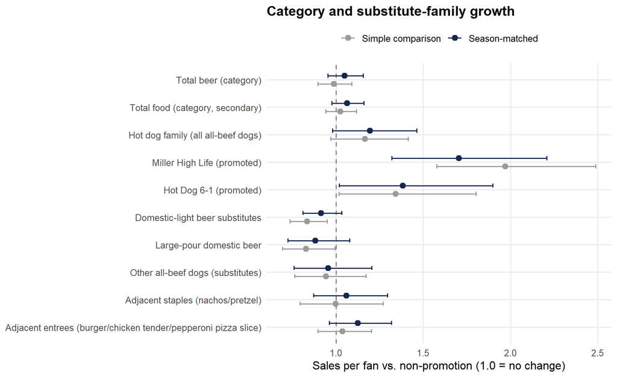

Figure 1: Change in sales per fan on promotion days, by group. Grey = simple comparison, navy = season-matched (compared to same-season non-promo games). Bars are 95% confidence ranges; dashed line at 1.0 = no change. When the navy dot sits on 1.0, there is no reliable category effect.

```r
gr %>%
  mutate(label = factor(label, levels = rev(unique(gr$label[order(gr$kind)]))),
         lens = factor(lens_label[model], levels = c("Simple comparison", "Season-matched"))) %>%
  ggplot(aes(rate_ratio, label, color = lens)) +
  geom_vline(xintercept = 1, linetype = "dashed", color = "grey50") +
  geom_errorbar(aes(xmin = ci_low, xmax = ci_high), orientation = "y",
                width = 0.3, position = position_dodge(width = 0.6)) +
  geom_point(size = 2.4, position = position_dodge(width = 0.6)) +
  scale_color_manual(values = pal_lens, name = NULL) +
  labs(x = "Sales per fan vs. non-promotion (1.0 = no change)", y = NULL,
       title = "Category and substitute-family growth")
```

Sales per fan on promotion vs. non-promotion days. 19 beer promotion games, 13 hot dog promotion games.

| Group | Type | Lens | Change per fan | 95% range | p-value |
| --- | --- | --- | --- | --- | --- |
| Total beer (category) | category | Simple comparison | -1.2% | 0.90 to 1.09 | 0.806 |
| Total beer (category) | category | Season-matched | +5.0% | 0.95 to 1.16 | 0.322 |
| Domestic-light beer substitutes | substitute | Simple comparison | -16.4% | 0.74 to 0.95 | 0.005 |
| Domestic-light beer substitutes | substitute | Season-matched | -8.5% | 0.81 to 1.03 | 0.155 |
| Large-pour domestic beer | substitute | Simple comparison | -17.2% | 0.69 to 1.00 | 0.039 |
| Large-pour domestic beer | substitute | Season-matched | -11.7% | 0.72 to 1.08 | 0.221 |
| Miller High Life (promoted) | promoted | Simple comparison | +97.1% | 1.58 to 2.49 | < 0.001 |
| Miller High Life (promoted) | promoted | Season-matched | +70.3% | 1.32 to 2.21 | < 0.001 |
| Total food (category, secondary) | category | Simple comparison | +2.5% | 0.94 to 1.12 | 0.568 |
| Total food (category, secondary) | category | Season-matched | +6.5% | 0.98 to 1.16 | 0.154 |
| Hot dog family (all all-beef dogs) | category | Simple comparison | +16.7% | 0.97 to 1.41 | 0.109 |
| Hot dog family (all all-beef dogs) | category | Season-matched | +19.5% | 0.98 to 1.46 | 0.075 |
| Other all-beef dogs (substitutes) | substitute | Simple comparison | -5.7% | 0.76 to 1.17 | 0.586 |
| Other all-beef dogs (substitutes) | substitute | Season-matched | -4.5% | 0.76 to 1.21 | 0.689 |
| Adjacent staples (nachos/pretzel) | substitute | Simple comparison | -0.1% | 0.79 to 1.27 | 0.994 |
| Adjacent staples (nachos/pretzel) | substitute | Season-matched | +6.0% | 0.87 to 1.30 | 0.570 |
| Adjacent entrees (burger/chicken tender/pepperoni pizza slice) | substitute | Simple comparison | +3.7% | 0.90 to 1.20 | 0.629 |
| Adjacent entrees (burger/chicken tender/pepperoni pizza slice) | substitute | Season-matched | +12.5% | 0.96 to 1.32 | 0.143 |
| Hot Dog 6-1 (promoted) | promoted | Simple comparison | +34.1% | 1.02 to 1.80 | 0.046 |
| Hot Dog 6-1 (promoted) | promoted | Season-matched | +38.4% | 1.02 to 1.90 | 0.037 |

Season-matched, total beer per fan is essentially flat and the domestic-light substitute family trends down but not significantly on the season-matched result. On the food side, the hot dog family trends up but also falls just short of significance. The item-level view below identifies which individual items drive these patterns.

The featured items do take a larger share of their family, as expected from a discount:

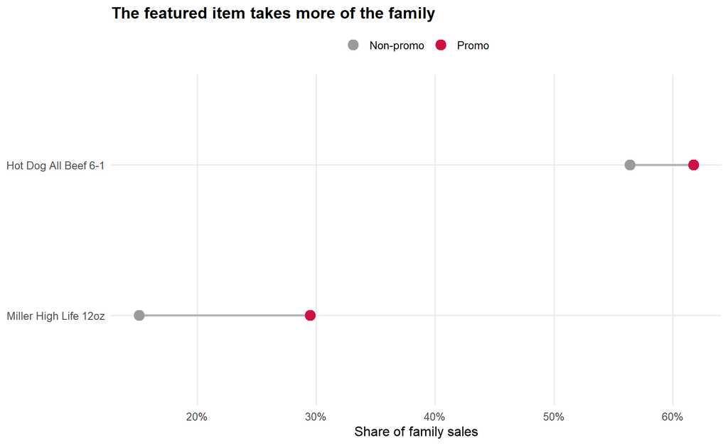

Figure 2: Share of family sales taken by the featured item, non-promotion vs. promotion days.

```r
fs %>% transmute(promoted_item, `Non-promo` = share_base, `Promo` = share_promo) %>%
  pivot_longer(-promoted_item, names_to = "grp", values_to = "share") %>%
  mutate(grp = factor(grp, levels = c("Non-promo", "Promo"))) %>%
  ggplot(aes(share, reorder(promoted_item, share), color = grp)) +
  geom_line(aes(group = promoted_item), color = "grey70", linewidth = 1) +
  geom_point(size = 4) +
  scale_color_manual(values = pal2, name = NULL) +
  scale_x_continuous(labels = scales::percent) +
  labs(x = "Share of family sales", y = NULL, title = "The featured item takes more of the family")
```

## 3.2 Within the same game, did the featured item pull ahead?

Comparing the featured item to its close substitutes inside the same game removes crowd size, weather, opponent, and day of week. A value below 1.0 means substitutes sold relatively less than the featured item when the promotion was on.

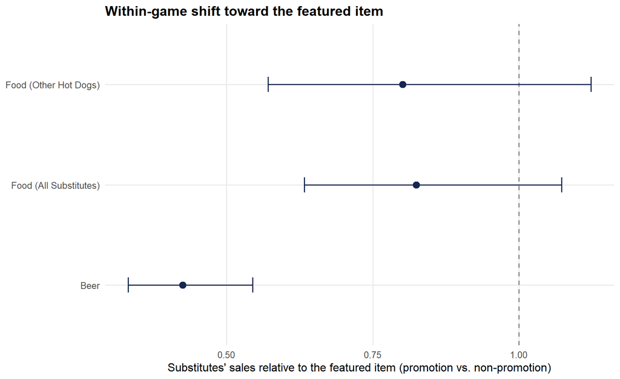

Figure 3: How close substitutes sold relative to the featured item, within the same game. Below 1.0 means the mix shifted toward the featured item. Bars are 95% confidence ranges.

```r
wg %>% mutate(category = str_to_title(category)) %>%
  ggplot(aes(rel_rate_ratio, category)) +
  geom_vline(xintercept = 1, linetype = "dashed", color = "grey50") +
  geom_point(size = 3, color = "#13274F") +
  geom_errorbar(aes(xmin = ci_low, xmax = ci_high), width = 0.15, color = "#13274F") +
  labs(x = "Substitutes' sales relative to the featured item (promotion vs. non-promotion)", y = NULL,
       title = "Within-game shift toward the featured item")
```

Within-game shift toward the featured item.

| Category | Featured item | Games | Substitutes | Relative sales | 95% range | p-value |
| --- | --- | --- | --- | --- | --- | --- |
| Beer | Miller High Life 12oz | 162 | 4 | 0.425 | 0.33 to 0.54 | < 0.001 |
| Food (Other Hot Dogs) | Hot Dog All Beef 6-1 | 140 | 2 | 0.801 | 0.57 to 1.12 | 0.198 |
| Food (All Substitutes) | Hot Dog All Beef 6-1 | 140 | 7 | 0.824 | 0.63 to 1.07 | 0.151 |

## 3.3 Item by item

Each item is shown two ways: the simple comparison and the season-matched comparison. The line connects the two, so items that move a lot between them were being driven by seasonal timing, not the promotion.

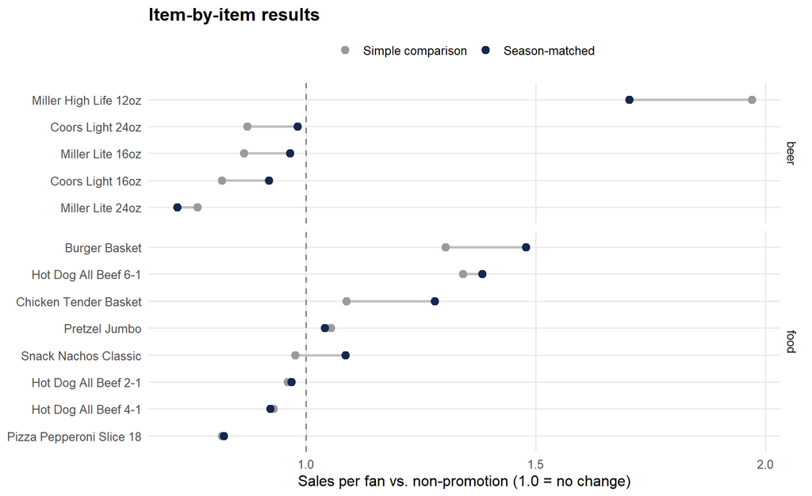

Figure 4: Each item’s sales change on promotion days: simple comparison (grey) vs. season-matched (navy). Featured and substitute items only. Dashed line at 1.0 = no change.

```r
ir %>% filter((is_substitute == 1 | is_promoted == 1), !is.na(rate_ratio), !is.na(rr_adj)) %>%
  select(name, category, tier = rate_ratio, adjusted = rr_adj) %>%
  pivot_longer(c(tier, adjusted), names_to = "model", values_to = "rr") %>%
  mutate(lens = factor(ifelse(model == "tier", "Simple comparison", "Season-matched"),
                       levels = c("Simple comparison", "Season-matched"))) %>%
  ggplot(aes(rr, reorder(name, rr))) +
  geom_vline(xintercept = 1, linetype = "dashed", color = "grey50") +
  geom_line(aes(group = name), color = "grey75", linewidth = 0.9) +
  geom_point(aes(color = lens), size = 2.6) +
  facet_grid(category ~ ., scales = "free_y", space = "free_y") +
  scale_color_manual(values = pal_lens, name = NULL) +
  labs(x = "Sales per fan vs. non-promotion (1.0 = no change)", y = NULL,
       title = "Item-by-item results")
```

Item-by-item change in sales per fan. ‘Season-matched’ is the result we rely on. ‘Multi-test p’ corrects the season-matched result for testing many substitutes at once.

| Category | Item | Role | Simple % | Season-matched % | Season-matched p | Multi-test p |
| --- | --- | --- | --- | --- | --- | --- |
| Beer | Miller High Life 12oz | featured | +97.1% | +70.3% | < 0.001 | n/a |
| Beer | Coors Light 16oz | substitute | -18.4% | -8.1% | 0.417 | 0.875 |
| Beer | Miller Lite 24oz | substitute | -23.7% | -28.1% | 0.021 | 0.114 |
| Beer | Coors Light 24oz | substitute | -12.9% | -1.9% | 0.875 | 0.875 |
| Beer | Miller Lite 16oz | substitute | -13.5% | -3.5% | 0.780 | 0.875 |
| Food | Hot Dog All Beef 6-1 | featured | +34.1% | +38.4% | 0.037 | n/a |
| Food | Burger Basket | substitute | +30.4% | +47.9% | 0.018 | 0.114 |
| Food | Pizza Pepperoni Slice 18 | substitute | -18.3% | -17.9% | 0.182 | 0.501 |
| Food | Chicken Tender Basket | substitute | +8.8% | +28.0% | 0.141 | 0.501 |
| Food | Hot Dog All Beef 4-1 | substitute | -7.1% | -7.8% | 0.625 | 0.875 |
| Food | Pretzel Jumbo | substitute | +5.4% | +4.1% | 0.810 | 0.875 |
| Food | Hot Dog All Beef 2-1 | substitute | -4.1% | -3.2% | 0.852 | 0.875 |
| Food | Snack Nachos Classic | substitute | -2.3% | +8.6% | 0.602 | 0.875 |

The simple comparison suggests several beer substitutes move, but some of those effects shrink once we match on season. Among the beer substitutes, Coors Light 16oz (-8.1%, p = 0.417) and Miller Lite 16oz (-3.5%, p = 0.780) both trend down after season matching but neither reaches significance individually. On the food side, the other hot dog sizes (4-1, 2-1) show small declines that are not significant, while burger basket and chicken tender basket trend up rather than down - no clear evidence of cannibalization from adjacent items at the ballpark-wide level.

### 3.3.1 Power

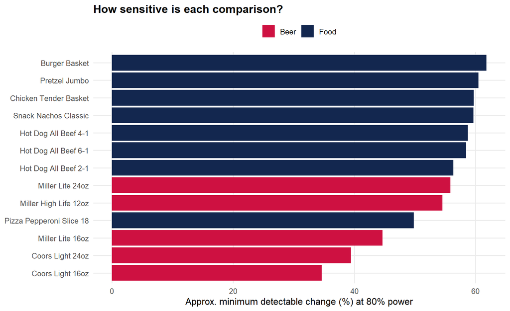

Figure 5: Approximate minimum detectable change (per fan, 80% power) per item. Large values mean a real moderate effect could go undetected, especially the low-volume beers and the 13-game food comparisons.

```r
ir %>% filter(!is.na(mde_pct_80_approx), is_substitute == 1 | is_promoted == 1) %>%
  mutate(category = str_to_title(category)) %>%
  ggplot(aes(mde_pct_80_approx, reorder(name, mde_pct_80_approx), fill = category)) +
  geom_col() +
  scale_fill_manual(values = c("Beer" = "#CE1141", "Food" = "#13274F"), name = NULL) +
  labs(x = "Approx. minimum detectable change (%) at 80% power", y = NULL,
       title = "How sensitive is each comparison?")
```

## 3.4 Market stands: did the promotions draw traffic?

This is the only view specific to the Market. We compare the change at the promotion Market stands (C343 MARKET, C313 MARKET) to the change at similar comparison stands, so a generally busy day affects both and cancels out.

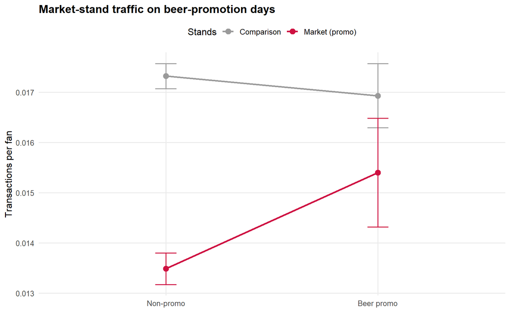

Figure 6: Transactions per fan by stand group and day type, on beer-promotion days. A steeper promotion-day rise for the Market stands is the promotion’s added effect.

```r
sp %>%
  filter(beer_promo == 1 | concession_promotion == 0, Tier %in% meta$beer_relevant_tiers) %>%
  mutate(Stands = ifelse(treated == 1, "Market (promo)", "Comparison"),
         Day = factor(ifelse(beer_promo == 1, "Beer promo", "Non-promo"), levels = c("Non-promo", "Beer promo"))) %>%
  group_by(Stands, Day) %>%
  summarise(mean = mean(trans_per_turnstile), se = sd(trans_per_turnstile) / sqrt(n()), .groups = "drop") %>%
  ggplot(aes(Day, mean, color = Stands, group = Stands)) +
  geom_line(linewidth = 1) + geom_point(size = 3) +
  geom_errorbar(aes(ymin = mean - se, ymax = mean + se), width = 0.1) +
  scale_color_manual(values = c("Market (promo)" = "#CE1141", "Comparison" = "#9A9A9A")) +
  labs(x = NULL, y = "Transactions per fan", title = "Market-stand traffic on beer-promotion days")
```

Added change at the Market stands on each promotion’s days, versus comparison stands.

| Promotion | Measure | Added effect | Std. error | p-value | Promo games | Base games |
| --- | --- | --- | --- | --- | --- | --- |
| Beer promo | transactions per fan (linear) | 0.0022 | 0.0015 | 0.148 | 19 | 143 |
| Beer promo | revenue per fan (linear) | 0.0136 | 0.0191 | 0.478 | 19 | 143 |
| Beer promo | transactions (Poisson, offset) | 0.1575 | 0.1002 | 0.116 | 19 | 143 |
| Food (hot dog) promo | transactions per fan (linear) | 0.0027 | 0.0018 | 0.132 | 13 | 127 |
| Food (hot dog) promo | revenue per fan (linear) | 0.0290 | 0.0232 | 0.214 | 13 | 127 |
| Food (hot dog) promo | transactions (Poisson, offset) | 0.2107 | 0.1237 | 0.088 | 13 | 127 |
| Any concession promo (combined) | transactions per fan (linear) | 0.0022 | 0.0011 | 0.052 | 29 | 133 |
| Any concession promo (combined) | revenue per fan (linear) | 0.0183 | 0.0143 | 0.201 | 29 | 133 |
| Any concession promo (combined) | transactions (Poisson, offset) | 0.1525 | 0.0775 | 0.049 | 29 | 133 |